# Advisor choice (dates)

[Matt Jaquiery](https://github.com/mjaquiery) (matt.jaquiery@psy.ox.ac.uk)

May 2020

[Script run 2020-05-11 13:19:41]

# Introduction

We have [previously observed](https://oxacclab.github.io/ExploringSocialMetacognition/analysis/ACv2/writeUp_v1.0.1.html) that people are more influenced by accurate over agreeing advisors when given feedback, and by agreeing over accurate advisors when denied feedback. Here we seek to extend that finding to the domain of source selection by offering participants a choice of advisor.

# Method

Participants are trained on an estimation decision task (dates task) and familiarised with two advisors within a judge-advisor system, one of who offers advisory estimates close to the participant’s initial estimate (‘agreeing advisor’) and one who offers advisory estimates close to the true answer (‘accurate advisor’). In the test phase, participants are allowed to choose which of the two advisors will give them advice on each trial.

The experimental code is available on [GitHub](https://github.com/oxacclab/ExploringSocialMetacognition), and the experiment can be performed by visiting [https://acclab.psy.ox.ac.uk/~mj221/ESM/ACv2/ac.html](https://acclab.psy.ox.ac.uk/~mj221/ESM/ACv2/ac.html?PROLIFIC_PID=WriteUp).

# Results

## Exclusions

```
##
##                                       Feedback.AgreeFirst
##   adviceColumnsNumeric eightKeyTrials                   1
##   badMarker                                             0
##   badMarker eightKeyTrials                              1
##   eightKeyTrials                                        0
##   FALSE                                                 6
##   outlyingTrials                                        0
##   pChange eightKeyTrials                                1
##
##                                       Feedback.AccurateFirst
##   adviceColumnsNumeric eightKeyTrials                      1
##   badMarker                                                0
##   badMarker eightKeyTrials                                 0
##   eightKeyTrials                                           0
##   FALSE                                                    6
##   outlyingTrials                                           1
##   pChange eightKeyTrials                                   0
##
##                                       Nofeedback.AgreeFirst
##   adviceColumnsNumeric eightKeyTrials                     0
##   badMarker                                               0
##   badMarker eightKeyTrials                                1
##   eightKeyTrials                                          2
##   FALSE                                                   7
##   outlyingTrials                                          0
##   pChange eightKeyTrials                                  0
##
##                                       Nofeedback.AccurateFirst
##   adviceColumnsNumeric eightKeyTrials                        0
##   badMarker                                                  1
##   badMarker eightKeyTrials                                   0
##   eightKeyTrials                                             0
##   FALSE                                                      9
##   outlyingTrials                                             0
##   pChange eightKeyTrials                                     0
```

Our final participant list consists of 28 participants who completed an average of 27.79 trials each. There were 12 participants in the Feedback condition, and 16 in the No feedback condition.

## Task performance

First we offer a characterisation of the task, to provide the reader with a sense of how the participants performed.

### Decisions

Participants offered estimates of whether various events took place before or after a given year. The correct answers were always between 1900 and 2000. Participants answered selecting a marker from a pool of available markers and dragging it onto a timeline to cover a range of dates within which they thought the event took place.

#### Correctness

Correct answers are those in which the chosen marker covers the year in which the event took place.

| decision | mean | CL95.Low | CL95.High | Phase |
| --- | --- | --- | --- | --- |
| first | .393 | .325 | .460 | Familiarization |
| last | .538 | .481 | .595 | Familiarization |
| Overall | .465 | .407 | .524 | Familiarization |

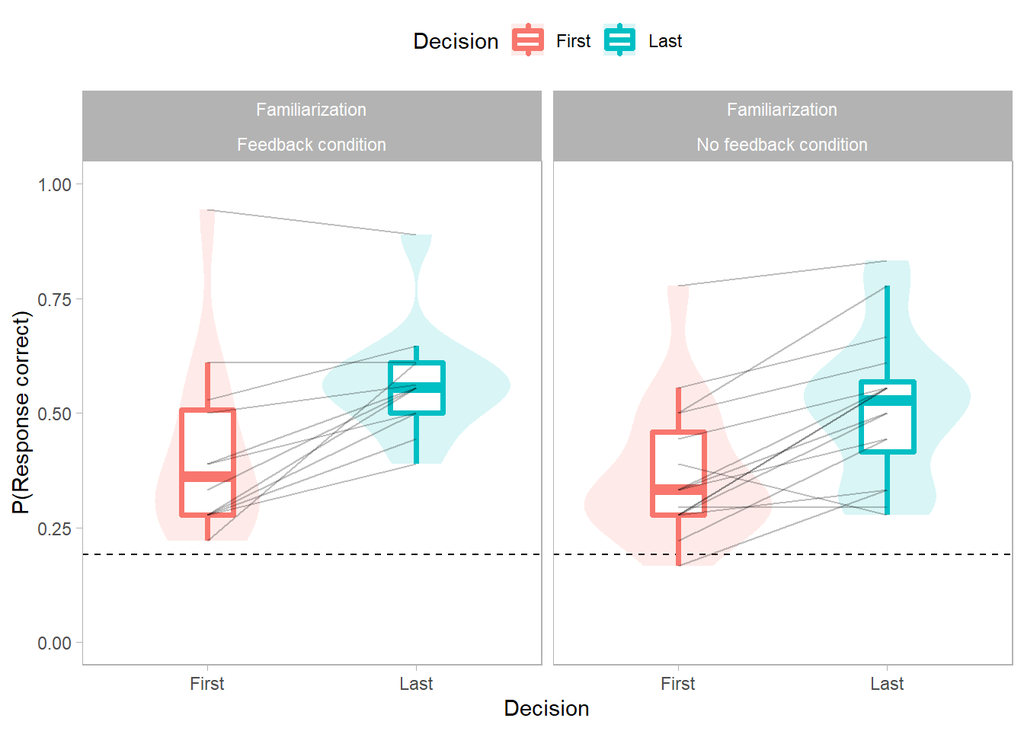

### Error

Error is the distance in years between the centre of the marker and the correct year. Note that when using smaller markers it is possible for answers to be incorrect (the marker doesn’t cover the correct year) while still having relatively low error (the centre of the marker is close to the correct year).

| decision | mean | CL95.Low | CL95.High | Phase |
| --- | --- | --- | --- | --- |
| first | 22.5 | 20.1 | 24.9 | Familiarization |
| last | 18.3 | 16.1 | 20.6 | Familiarization |
| Overall | 20.4 | 18.2 | 22.6 | Familiarization |

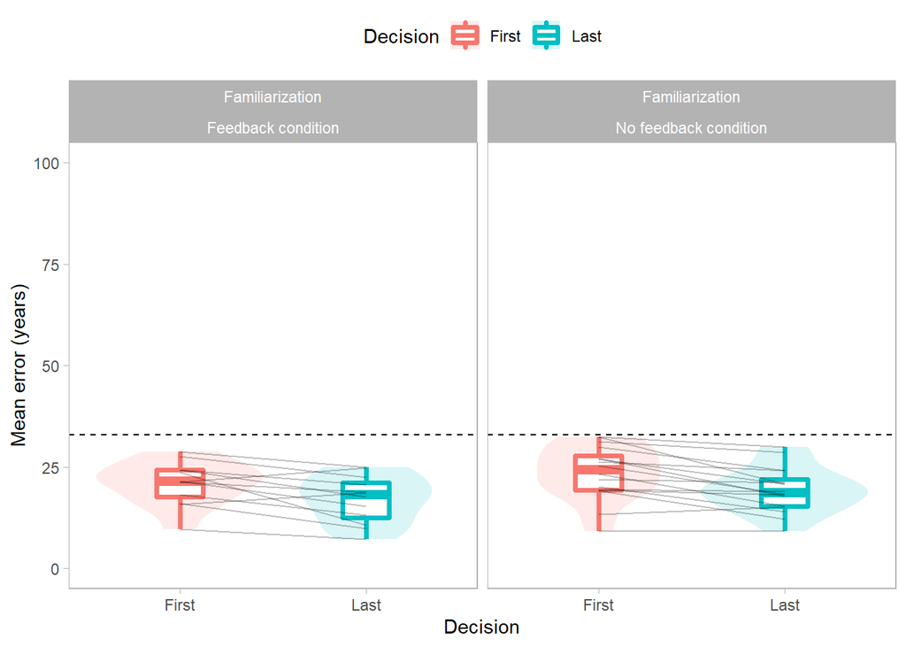

### Timing

We can look at the response time - the difference between the time the response is opened and the time the response is received.

| decision | mean | CL95.Low | CL95.High | Phase |
| --- | --- | --- | --- | --- |
| first | 10841 | 8610 | 13072 | Familiarization |
| last | 5471 | 4646 | 6297 | Familiarization |
| Overall | 8156 | 6722 | 9591 | Familiarization |

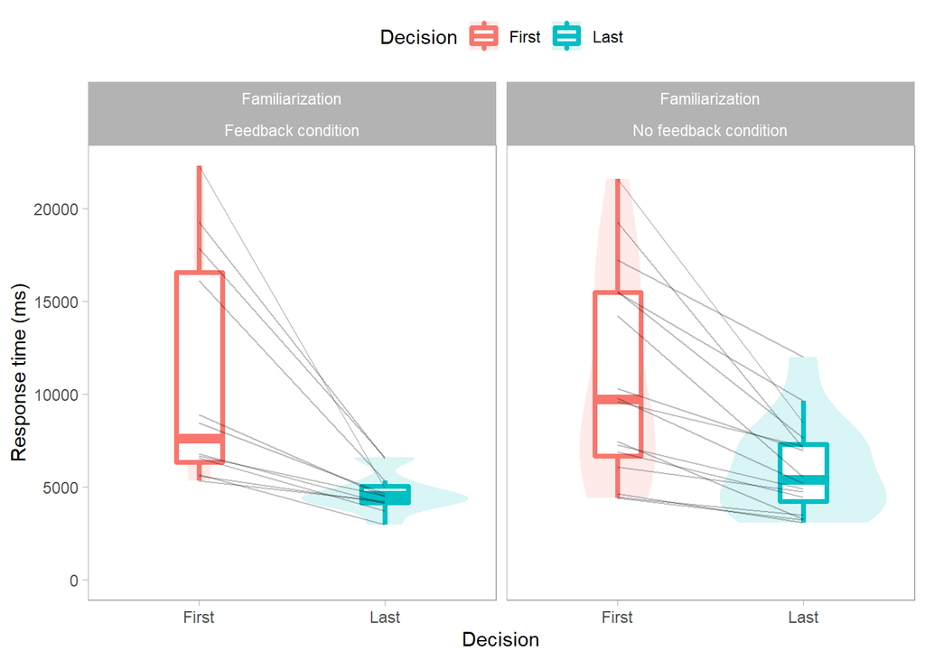

### Summary

Participants were able to perform the task appropriately: their responses were better than would be expected by chance both in terms of the difference between the correct answer and the response marker placement and in terms of the rate at which the response marker placement covered the correct answer.

## Metacognitive performance

### Marker usage

Participants could select one of three markers, each spanning a different number of years. They were awarded more points for selecting slimmer markers.

| decision | feedback | mean\|m=21 | mean\|m=13 | mean\|m=7 |
| --- | --- | --- | --- | --- |
| first | FALSE | .395 | .400 | .205 |
| first | TRUE | .467 | .282 | .251 |
| first | NA | .426 | .350 | .225 |

| decision | feedback | mean\|m=21 | mean\|m=13 | mean\|m=7 |
| --- | --- | --- | --- | --- |
| last | FALSE | .266 | .428 | .306 |
| last | TRUE | .377 | .338 | .284 |
| last | NA | .314 | .390 | .296 |

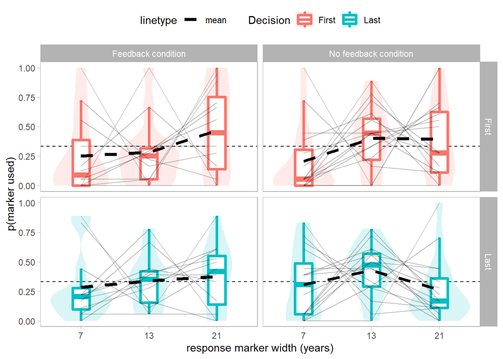

#### Feedback condition by advisor

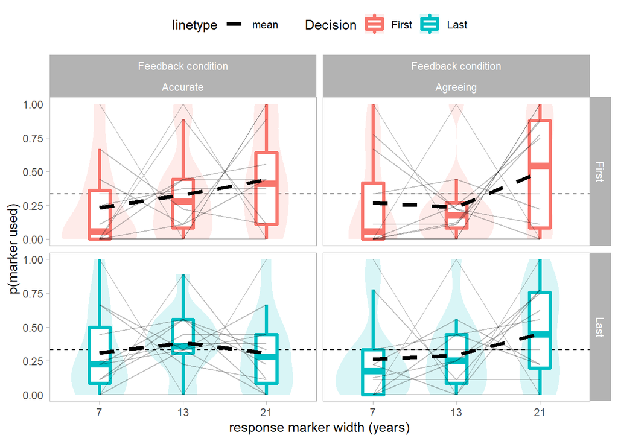

### Relationship between marker width and error

Participants indicated the confidence in their decisions simultaneously with the decisions themselves through their choice of which marker to use. We can thus explore how well a participant’s confidence signals their accuracy. We expect that slimmer markers will be associated with less error.

| decision | feedback | mean\|m=21 | mean\|m=13 | mean\|m=7 | mean |
| --- | --- | --- | --- | --- | --- |
| first | FALSE | 31.6 | 23.5 | 13.3 | 23.6 |
| first | TRUE | 23.6 | 17.8 | 16.5 | 21.0 |
| first | NA | 28.3 | 21.1 | 14.7 | 22.5 |

| decision | feedback | mean\|m=21 | mean\|m=13 | mean\|m=7 | mean |
| --- | --- | --- | --- | --- | --- |
| last | FALSE | 25.4 | 20.6 | 13.0 | 19.3 |
| last | TRUE | 21.9 | 14.0 | 10.4 | 17.0 |
| last | NA | 24.0 | 17.7 | 11.8 | 18.3 |

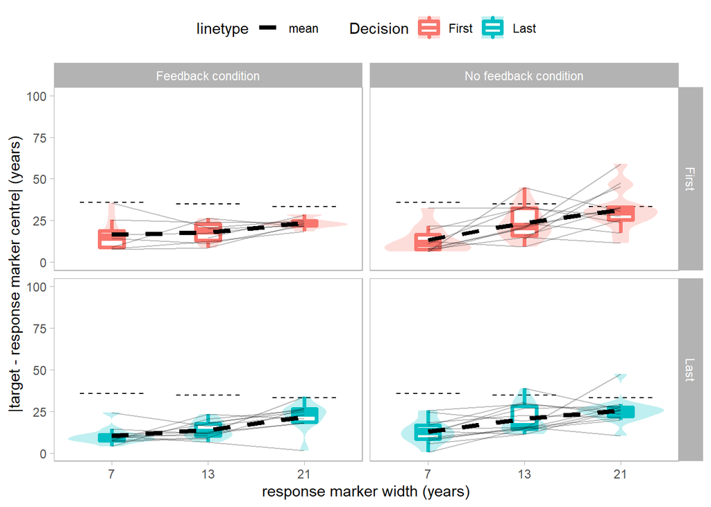

### Summary

Participants made use of all the markers. The usage proportions for each marker were fairly similar to one another, especially in comparison with past data. In the feedback case it appears that participants tended to adopt a conservative marker width to begin with, relying on the advice to resolve their uncertainty. These participants often chose to select narrow markers where the Accurate advisor was providing advice, while retaining the widest marker when the Agreeing advisor was providing advice. The participants in the No feedback condition appeared to increase their confidence (by using slimmer markers) on final decisions as compared with initial estimates.

The mean error showed a tendency to increase with the marker width, indicating that participants were using wider markers where they were less close to the correct answer, presumably reflecting a decrease in confidence which accompanied the decreased accuracy.

## Advisor performance

Participants in should get an appropriate experience of each advisor during familiarisation. The accurate advisor should have low error, while the agreeing advisor should have low distance (a measure of the distance between the centre of the advice and the participant’s initial estimate).

### Error

| advisor0idDescription | FeedbackCondition | adviceError | adviceDistance |
| --- | --- | --- | --- |
| Accurate | Feedback condition | 4.949 | 19.481 |
| Accurate | No feedback condition | 6.009 | 19.753 |
| Agreeing | Feedback condition | 16.105 | 7.649 |
| Agreeing | No feedback condition | 18.581 | 7.554 |

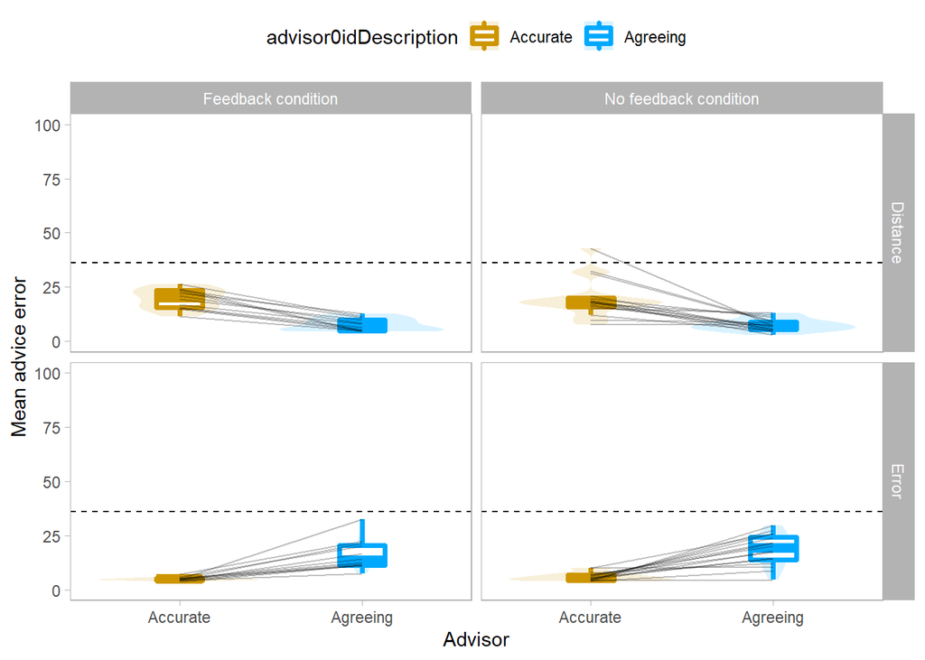

### Summary

The advisors offered advice which was better than chance. The Accurate advisors were more accurate than the Agreeing advisors, and the Agreeing advisors offered answers which were closer to the participants’ initial estimates than the Accurate advisors.

## Advice during Familiarization

The participants had a familiarization block with each of the advisors individually. While these blocks are relatively short, learning may be rapid enough to demonstrate differences in influence.

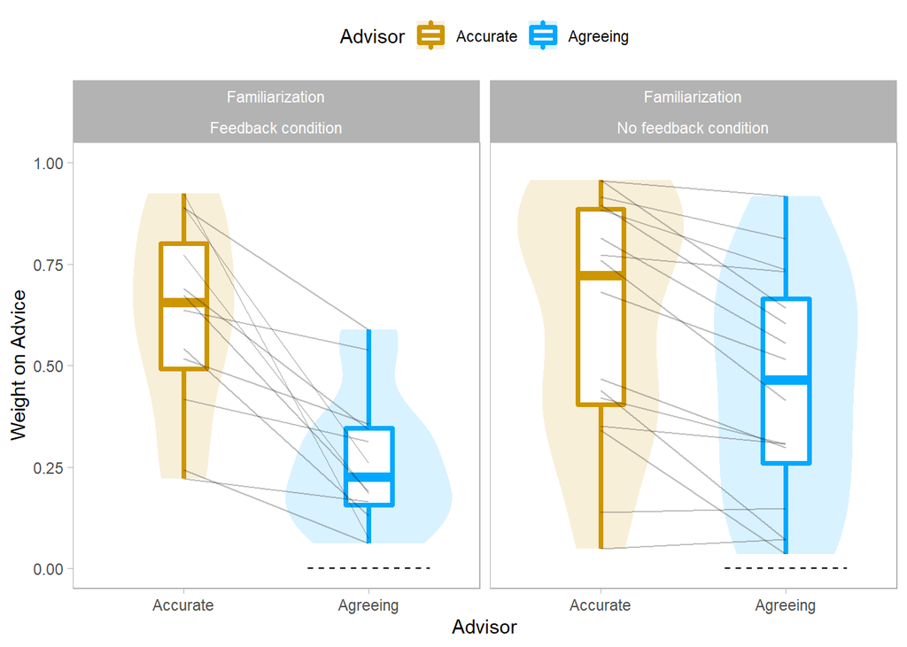

We included a couple of trials in each familiarization block where the advisors gave matched advice. We can compare influence just on those trials.

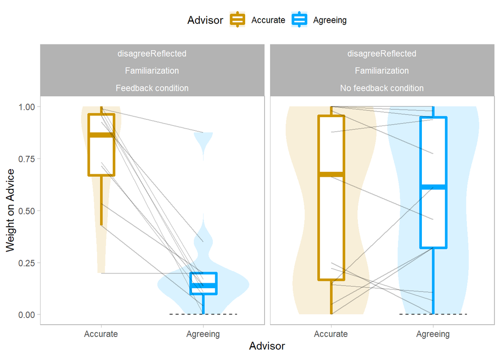

## Hypothesis testing

The hypotheses being tested here are:

1. Participants’ pick rates for the two advisors will differ by condition.
2. Participants in the Feedback condition will pick the Accurate advisor more than the Agreeing advisor.
3. Participants in the No feedback condition will pick the Agreeing advisor more than the Accurate advisor.

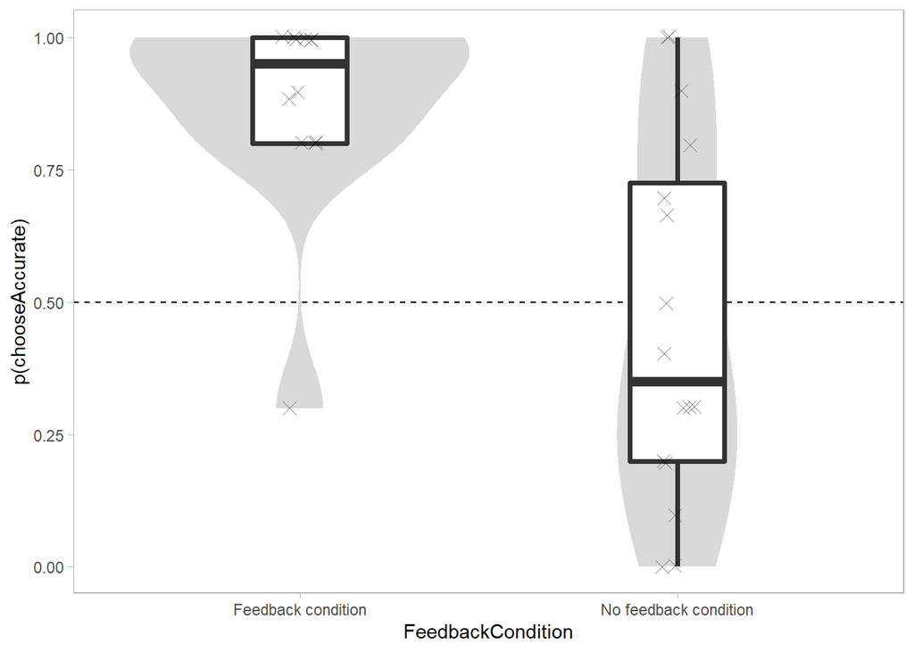

```
## Bayes factor analysis
## --------------
## [1] Alt., r=0.707 : 31.5084 ±0%
##
## Against denominator:
##   Null, mu1-mu2 = 0
## ---
## Bayes factor type: BFindepSample, JZS
```

```
## Bayes factor analysis
## --------------
## [1] Alt., r=0.707 : 561.1615 ±0%
##
## Against denominator:
##   Null, mu = 0.5
## ---
## Bayes factor type: BFoneSample, JZS
```

```
## Bayes factor analysis
## --------------
## [1] Alt., r=0.707 : 0.2807044 ±0%
##
## Against denominator:
##   Null, mu = 0.5
## ---
## Bayes factor type: BFoneSample, JZS
```

### Summary

Participants in the two conditions showed different pick rates. Participants in the Feedback condition preferred to pick the Accurate advisor. Participants in the No feedback condition did not have a systematic preference, although there was a tendency to prefer the Agreeing advisor.

## Exploration

### Influence during Familiarization x Pick preference

```
## [1] ">> Feedback condition"
```

```
##
##  Pearson's product-moment correlation
##
## data:  n and woa
## t = -1.8345, df = 10, p-value = 0.09647
## alternative hypothesis: true correlation is not equal to 0
## 95 percent confidence interval:
##  -0.8351796  0.1012736
## sample estimates:
##        cor
## -0.5017927
```

```
## [1] ">> No feedback condition"
```

```
##
##  Pearson's product-moment correlation
##
## data:  n and woa
## t = -0.54579, df = 14, p-value = 0.5938
## alternative hypothesis: true correlation is not equal to 0
## 95 percent confidence interval:
##  -0.5973084  0.3784423
## sample estimates:
##        cor
## -0.1443407
```

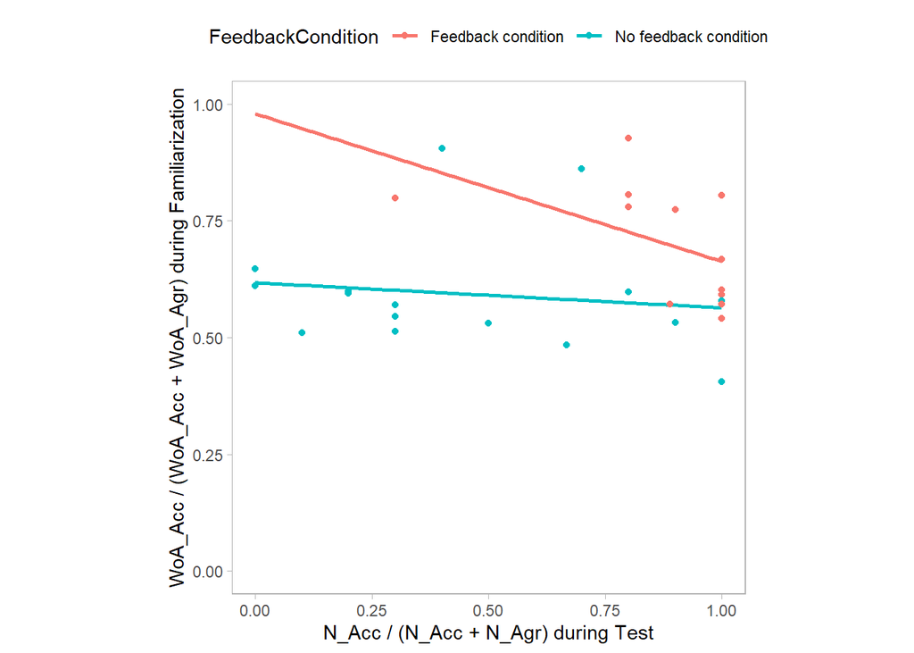

We really ought to check this using the disagreeReflected trials only.

```
## [1] ">> Feedback condition (disagreeReflected trials only)"
```

```
##
##  Pearson's product-moment correlation
##
## data:  n and woa
## t = -0.34144, df = 10, p-value = 0.7398
## alternative hypothesis: true correlation is not equal to 0
## 95 percent confidence interval:
##  -0.6417155  0.4971835
## sample estimates:
##        cor
## -0.1073483
```

```
## [1] ">> No feedback condition (disagreeReflected trials only)"
```

```
##
##  Pearson's product-moment correlation
##
## data:  n and woa
## t = -1.5553, df = 13, p-value = 0.1439
## alternative hypothesis: true correlation is not equal to 0
## 95 percent confidence interval:
##  -0.7551302  0.1457544
## sample estimates:
##        cor
## -0.3960817
```

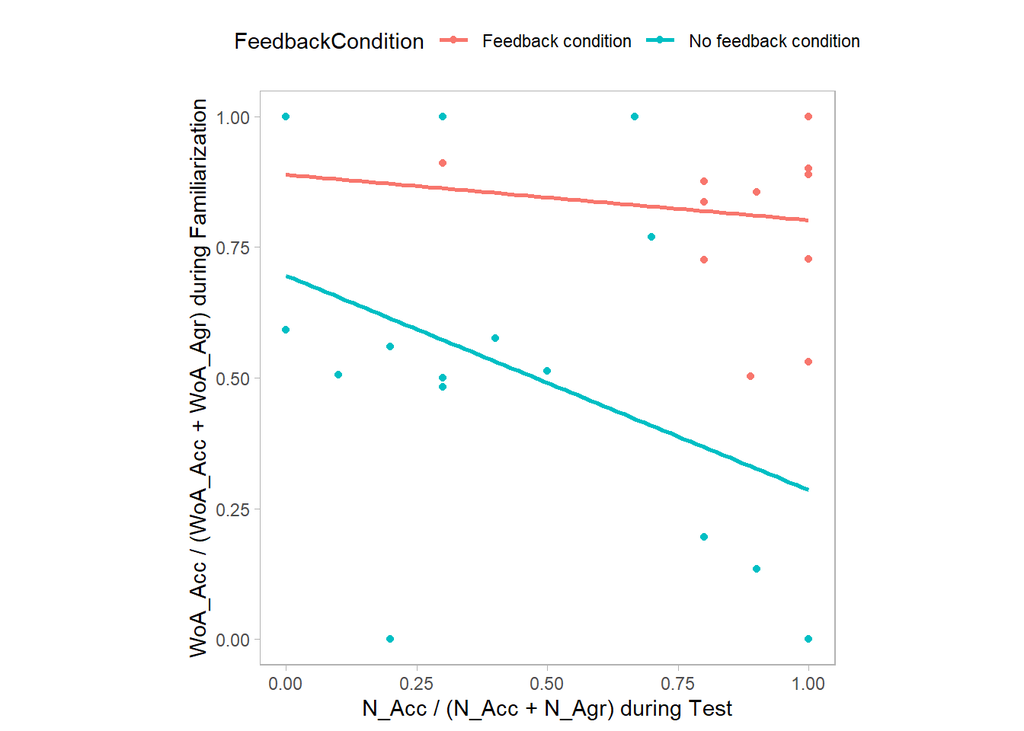

### Offbrand trial numbers

We want to know how much experience with an advisor each participant had before they got the offbrand trials used to calculate influence.

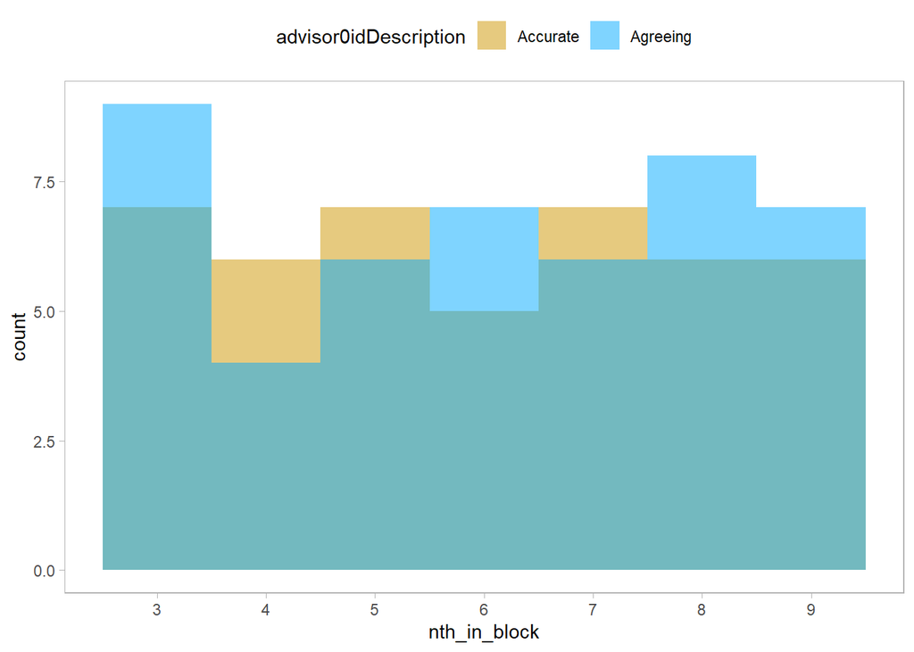

### Advisor ratings

We can look at the questionnaire items for the advisors, too.

| pid | knowledge | helpfulness | likability | comment | advisorId | FeedbackCondition | woa | n | idDescription |
| --- | --- | --- | --- | --- | --- | --- | --- | --- | --- |
| 82f34428 | 18 | 0 | 18 | This advisor seemed to guess right around my initial answers | 2 | No feedback condition | 0.1951220 | 0.8000000 | Agreeing |
| 82f34428 | 71 | 81 | 50 |  | 1 | No feedback condition | 0.1951220 | 0.8000000 | Accurate |
| b095317d | 89 | 89 | 83 |  | 1 | Feedback condition | 0.9013296 | 1.0000000 | Accurate |
| b095317d | 27 | 27 | 52 |  | 2 | Feedback condition | 0.9013296 | 1.0000000 | Agreeing |
| 00a37027 | 62 | 39 | 72 | I was almost never sure about the answer and he always agreed with me which on the one hand makes me think that I'm right but in the other hand it was kind of suspicious. I'm confused about his actual… | 2 | No feedback condition | 1.0000000 | 0.6666667 | Agreeing |
| 00a37027 | 57 | 78 | 34 | This advisor most of the time put other answer then mine which was annoying at some point but at least it gave me a reason to think deeper about the questions. I took his oppinion in account because I… | 1 | No feedback condition | 1.0000000 | 0.6666667 | Accurate |
| c344a7b8 | 85 | 86 | 50 |  | 1 | Feedback condition | 0.7272727 | 1.0000000 | Accurate |
| c344a7b8 | 28 | 27 | 50 |  | 2 | Feedback condition | 0.7272727 | 1.0000000 | Agreeing |
| 13c16a08 | 89 | 89 | 71 | confident in his assumptions | 1 | Feedback condition | 0.7255764 | 0.8000000 | Accurate |
| 13c16a08 | 50 | 14 | 90 | silly but cute | 2 | Feedback condition | 0.7255764 | 0.8000000 | Agreeing |

[output cut: 46 more lines]

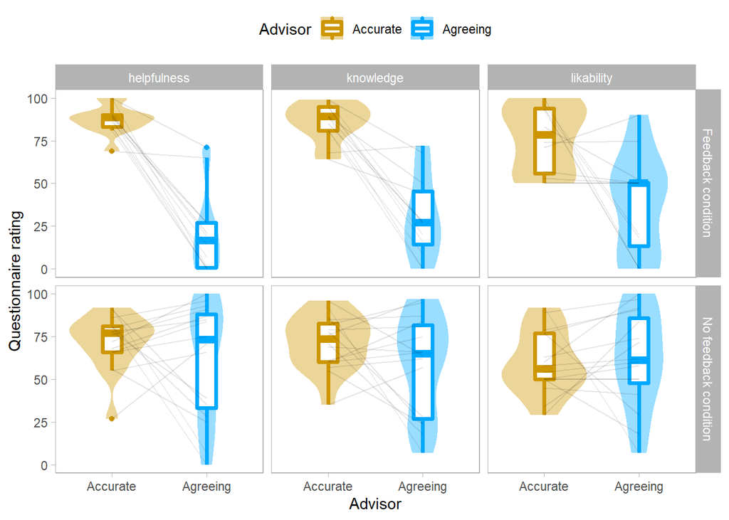

[output not shown]

[output not shown]

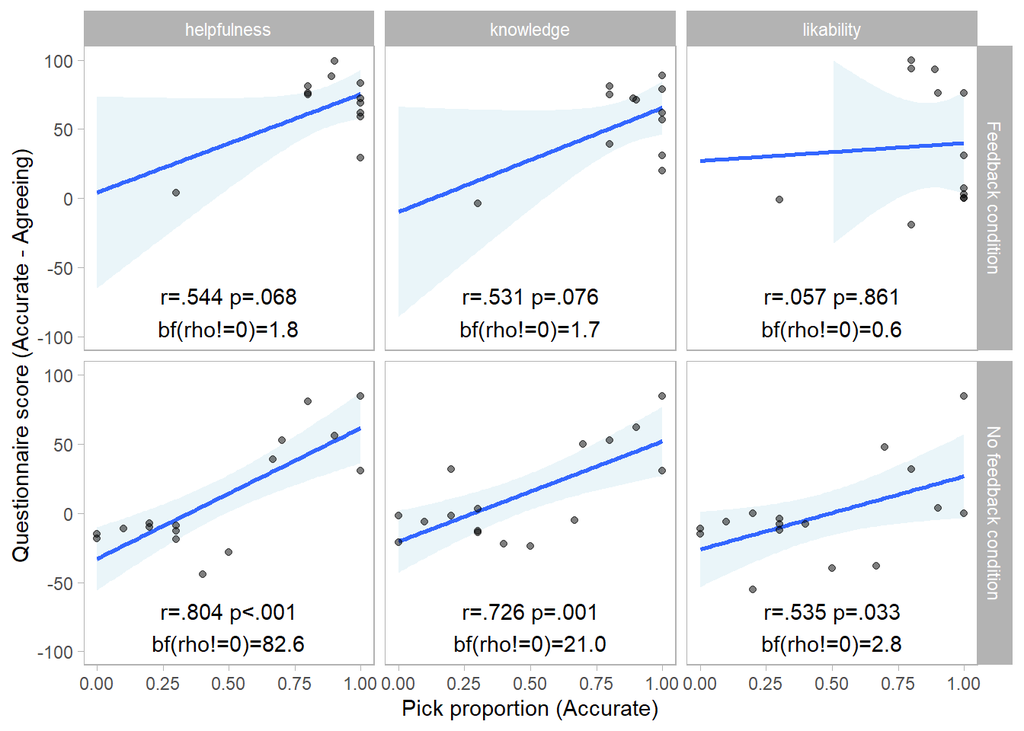

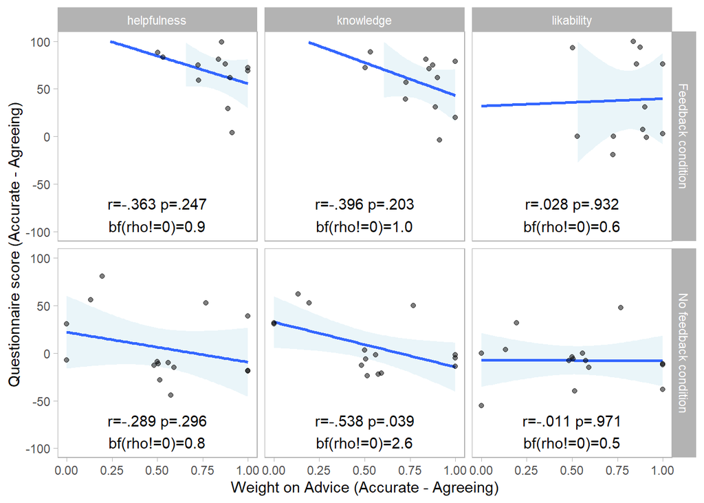

#### Summary

The participants’ subjective ratings show some interesting patterns. In the Feedback condition, participants consistently rate the Accurate advisor as both more helpful and more knowledgeable. For around half of these participants, the Accurate advisor is also more likeable, while for the other half the likeability of the advisors is very similar. In the No feedback condition, the advisor preferences appear to be much more idiosyncratic, but they also appear to be stable across scales, so that an advisor rated highly for helpfulness will also be rated highly for likeability and knowledge.

The difference in ratings given to the two advisors also corresponds quite well with the rate at which that advisor is picked. The higher the ratings for the Accurate advisor compared to the Agreeing advisor, the more frequently the Accurate advisor is picked, for both conditions. This makes sense, but because these measures are taken after the choosing phase an alternate explanation remains plausible; that the more exposed to (i.e. familiar with) an advisor a participant is, the higher they will rate them on arbitrary scales.

The correlations for weight on advice difference with questionnaire rating difference are not very pronounced, and they do not appear to refelect much more than noise, according to the statistical tests. Numerically, they go in the ‘wrong’ direction: in almost all cases the lower the weight on advice of the Accurate advisor compared to the Agreeing advisor, the higher the rating of the Accurate advisor compared to the Agreeing advisor.

# Conclusions

As we showed with influence, people can use feedback to identify a helpful advisor. Unlike the influence results, participants denied feedback did not show a preference for the Agreeing advisor, suggesting that source selection is substantially more robust to the agreement-driven updating than we hypothesised.

This finding should be replicated in a) a preregistered experiment and b) using the Dots task. If the finding that source selection is relatively unaffected by agreement-driven updating proves robust, this may be worth conducting further experiments to explore: is the tendency to prefer to pick the Agreeing advisor associated with metacognitive ability, need-for-certainty, or the like?

Future versions should probably ensure that offbrand trials come towards the end of the familiarization blocks to give a good indication of influence.

# Credits

## Acknowledgements

Thanks as always to Nick Yeung and the other folks at the [ACC Lab](https://www.psy.ox.ac.uk/research/attention-cognitive-control-lab).

## R Packages

| Package | Citations |
| --- | --- |
| base | R Core Team (2018). R: A language and environment for statistical computing. R Foundation for Statistical Computing, Vienna, Austria. URL https://www.R-project.org/. |
| beepr | Rasmus Bååth (2018). beepr: Easily Play Notification Sounds on any Platform. R package version 1.3. https://CRAN.R-project.org/package=beepr |
| curl | Jeroen Ooms (2019). curl: A Modern and Flexible Web Client for R. R package version 4.0. https://CRAN.R-project.org/package=curl |
| testthat | Hadley Wickham. testthat: Get Started with Testing. The R Journal, vol. 3, no. 1, pp. 5--10, 2011 |
| Hmisc | Frank E Harrell Jr, with contributions from Charles Dupont and many others. (2019). Hmisc: Harrell Miscellaneous. R package version 4.2-0. https://CRAN.R-project.org/package=Hmisc |
| Formula | Achim Zeileis, Yves Croissant (2010). Extended Model Formulas in R: Multiple Parts and Multiple Responses. Journal of Statistical Software 34(1), 1-13. doi:10.18637/jss.v034.i01 |
| survival |  |
| lattice | Sarkar, Deepayan (2008) Lattice: Multivariate Data Visualization with R. Springer, New York. ISBN 978-0-387-75968-5 |
| ez | Michael A. Lawrence (2016). ez: Easy Analysis and Visualization of Factorial Experiments. R package version 4.4-0. https://CRAN.R-project.org/package=ez |
| knitr | Yihui Xie (2019). knitr: A General-Purpose Package for Dynamic Report Generation in R. R package version 1.24.Yihui Xie (2015) Dynamic Documents with R and knitr. 2nd edition. Chapman and Hall/CRC. IS… |

[output cut: 15 more lines]

## Funding

Matt Jaquiery is funded by a studentship from the [Medical Research Council](https://mrc.ukri.org/) (reference 1943590) and the University of Oxford [Department of Experimental Psychology](https://www.psy.ox.ac.uk/) (reference 17/18_MSD_661552).